# Major/minor spliceosome analysis

Regina H. Reynolds

UCL

> Aim: determine whether the proportion of introns targeted by major/minor spliceosome differs between differentially spliced and non-differentially spliced introns across pairwise comparisons of disease to control

# 1 Background

- [Moyer at al.](https://academic.oup.com/nar/article/48/13/7066/5850313):
  - Introns can be excised through two distinct pathways: the major (> 99% of introns in most organisms) or minor (< 1% in most organisms, with some organisms lacking minor class introns altogether) spliceosomes.
  - Minor class introns have consensus splice site and branch point sequences distinct from major class introns.
  - The Intron Annotation and Orthology Database (IAOD) portal, contains the scores assigned to all Homo sapiens (GRCh38) introns that were recognisable either by the major spliceosome (U2-type introns) or by the minor spliceosome (U12-type introns).

# 2 Supplementary code

## 2.1 Loading IOAD data

```r
U2 <-
  read_delim(file = "https://introndb.lerner.ccf.org/static/bed/GRCh38_U2.bed",
             delim = "\t",
             col_names = c("chr", "start", "stop", "intron_id", "score", "strand"),
             col_types=
               list(col_character(),
                    col_double(),
                    col_double(),
                    col_character(),
                    col_double(),
                    col_character())) %>%
  dplyr::mutate(intron_type = "U2")

print(str_c("Number of U2 introns: ", nrow(U2)))
```

```
## [1] "Number of U2 introns: 221420"
```

```r
U12 <-
  read_delim(file = "https://introndb.lerner.ccf.org/static/bed/GRCh38_U12.bed",
             delim = "\t",
             col_names = c("chr", "start", "stop", "intron_id", "score", "strand"),
             col_types =
               list(col_character(),
                    col_double(),
                    col_double(),
                    col_character(),
                    col_double(),
                    col_character())) %>%
  dplyr::mutate(intron_type = "U12")

print(str_c("Number of U12 introns: ", nrow(U2)))
```

```
## [1] "Number of U12 introns: 221420"
```

```r
spliceosome_gr <-
  U2 %>%
  dplyr::bind_rows(U12) %>%
  makeGRangesFromDataFrame(
    keep.extra.columns = TRUE,
    seqnames.field = "chr",
    start.field = "start",
    end.field = "stop",
    strand.field = "strand"
    ) %>%
  GenomeInfoDb::keepSeqlevels(c(1:22, "X", "Y"),
                             pruning.mode = "coarse")
```

## 2.2 Loading differential splicing

```r
# List with 2 dataframes: (1) all successfully tested and annotated introns and (2) significant and annotated introns
# Significance: FDR < 0.05, cluster contains >= 1 intron with |dPSI| >= 0.1
intron_list <-
  readRDS(here::here("docs", "figures", "intron_list.Rds"))

# Add a column to dataframe with ds events signifying significance
# Left join this to the dataframe of all successfully tested events
# Replace NAs with FALSE
intron_ds <-
  intron_list[[1]] %>%
  dplyr::left_join(
    intron_list[[2]] %>%
                     dplyr::mutate(diff_spliced = TRUE)
    ) %>%
  dplyr::mutate(
    diff_spliced = case_when(is.na(diff_spliced) ~ FALSE,
                            TRUE ~ diff_spliced)
  )
intron_ds_gr <-
  intron_ds %>%
  dplyr::select(-width) %>%
  makeGRangesFromDataFrame(
    keep.extra.columns = TRUE,
    seqnames.field = "seqnames",
    start.field = "start",
    end.field = "end",
    strand.field = "strand"
    )
```

## 2.3 Finding overlaps

```r
# Looking only for exactly overlapping introns
overlap <-
  GenomicRanges::findOverlaps(
    intron_ds_gr,
    spliceosome_gr,
    type = "equal"
    ) %>%
  as_tibble()

overlap_df <-
  intron_ds_gr %>%
  as_tibble() %>%
  dplyr::left_join(
    intron_ds_gr %>%
      as_tibble() %>%
      dplyr::slice(overlap$queryHits) %>%
      dplyr::bind_cols(
        spliceosome_gr %>%
          as_tibble() %>%
          dplyr::select(intron_id, score, intron_type) %>%
          dplyr::rename_with(
            ~ stringr::str_c("ioad", .x, sep = "_")
          ) %>%
          dplyr::slice(overlap$subjectHits)
      )
  )
```

# 3 Results

## 3.1 Number of distinct leafcutter introns that overlap U2/U12 introns

### 3.1.1 Text

- Most introns from successfully tested intron clusters in each pairwise comparison were neither U2 nor U12 introns (Figure 3.1). Worth bearing in mind that:
  - IOAD GRCh38 was constructed using Ensembl v92, while we are using v97 (it does appear that we can create this file for v97, if we wanted to: https://github.com/Devlin-Moyer/cmdline_iaod)
  - Our leafcutter data contains introns that are not in annotation.
- Of those introns that were annotated, the majority were U2-type introns.

### 3.1.2 Figure

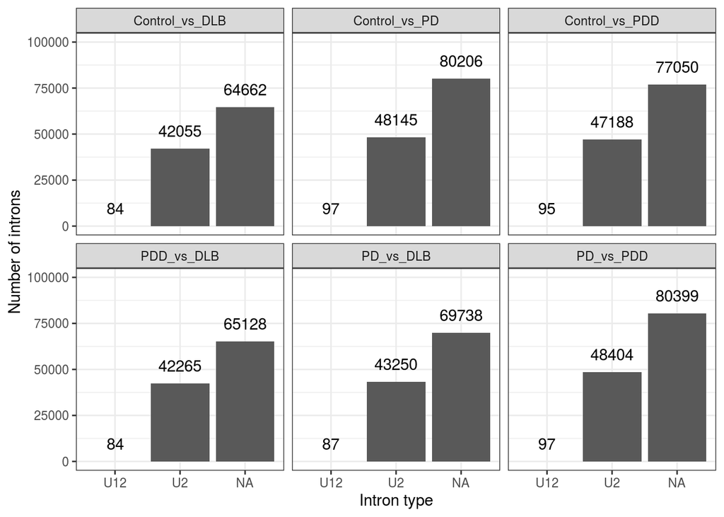

Figure 3.1: Number of introns within each intron type across pairwise comparisons.

```r
overlap_df %>%
  dplyr::filter(!junc_cat %in% c("ambig_gene")) %>%
  dplyr::distinct(
    comparison,
    seqnames,
    start,
    end,
    junc_cat,
    ioad_intron_type
    ) %>%
  ggplot(
    aes(x = ioad_intron_type)
    ) +
  geom_bar() +
  geom_text(
    stat='count',
    aes(label=..count..),
    vjust=-1
    ) +
  labs(
    x = "Intron type",
    y = "Number of introns"
  ) +
  facet_wrap(vars(comparison)) +
  expand_limits(y = c(0, 100000)) +
  theme_bw()
```

## 3.2 Proportion of U2/U12-type introns across differentially spliced and non-differentially spliced introns

### 3.2.1 Text

- Only two pairwise comparisons have differentially spliced introns that are considered a U12-type intron (Figure 3.2).
- The pattern of how the proportion of U12/U2-type introns changes across differentially and non-differentially spliced introns is inconsistent across the two pairwise comparisons.
  - Control vs DLB: proportion of U12-type introns appears to decrease in differentially spliced introns
  - PD vs DLB: proportion of U12-type introns appears to increase in differentially spliced introns
- Chi-squared test was applied to ask: *If there was no association between differential splicing of a cluster and intron type, what is the chance that random sampling would result in the association observed?*
- Only PD vs DLB returned a p-value < 0.05, suggesting that the chances of observing this contingency table, and by extension the overlap between differential splicing and intron type, by random chance is small (in this pairwise comparison).

### 3.2.2 Figure

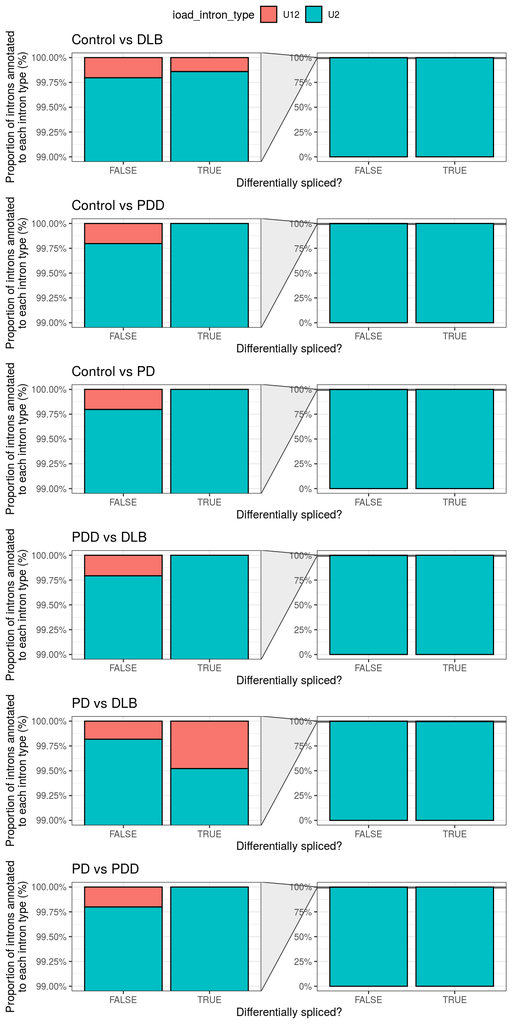

Figure 3.2: Proportion of U2 and U12 introns across differentially spliced and non-differentially spliced introns from each pairwise comparison. For each figure, the panel on the left is a zoomed view of the panel on the right.

```r
comparisons <- overlap_df$comparison %>% unique()

fig_list <-
  vector(mode = "list",
         length = length(comparisons))

for(i in 1:length(comparisons)){

  fig_list[[i]] <-
    overlap_df %>%
    dplyr::filter(
      !is.na(ioad_intron_type),
      comparison == comparisons[i]
    ) %>%
    ggplot(
      aes(
        x = diff_spliced,
        fill = ioad_intron_type
      )
    ) +
    geom_bar(position = "fill", colour = "black") +
    labs(
      x = "Differentially spliced?",
      y = "Proportion of introns annotated\nto each intron type (%)",
      title = comparisons[i] %>%
        stringr::str_replace_all("_", " ")
    ) +
    scale_y_continuous(labels = scales::percent) +
    ggforce::facet_zoom(ylim = c(0.99,1), zoom.size = 1) +
    theme_bw()

}

ggpubr::ggarrange(
  plotlist = fig_list,
  ncol = 1,
  common.legend = T
)
```

### 3.2.3 Chi-squared test

```r
overlap_df %>%
  dplyr::filter(!is.na(ioad_intron_type),
                comparison %in% c("Control_vs_DLB", "PD_vs_DLB")) %>%
  dplyr::select(comparison, diff_spliced, ioad_intron_type) %>%
  dplyr::group_by(comparison) %>%
  summarise(
    p.value= chisq.test(diff_spliced, ioad_intron_type)$p.value,
    method = chisq.test(diff_spliced, ioad_intron_type)$method
    )
```

| comparison | p.value | method |
| --- | --- | --- |
| Control_vs_DLB | 0.616839916 | Pearson's Chi-squared test with Yates' continuity correction |
| PD_vs_DLB | 0.001821963 | Pearson's Chi-squared test with Yates' continuity correction |